# Project7_UdacityDAND

Mohammed Essam Rashad

27 May 2019

## 1- Introduction

In this report, I will explore the red wine dataset with the following steps:

1- I will check on each individual attribute of this dataset and plot its distribution.

2- I will look at two attributes at a time to explore these sub-poits:

2.1- How each input attribute is related to the quality.  
2.2- Interesting finsings about some input attributes.

3- I will examine number of attributes by adding one additional attribute to some of the interesting two-attribute pairs.

4- I will summarize all i have been through in this project either for successes and problems i encounter during the data exploration process.

```r
##Load the needed packages
library(ggplot2)
library(corrplot)
library(RColorBrewer)
library(memisc)
library(gridExtra)
```

```r
##Load the dataset.
wine_reds = read.csv('C:/Users/merashadloc/Downloads/wineQualityReds.csv', row.names = 1)
```

## 2- Univariate Exploration

In this section, I will have a look at the structure of the data set. Then I will examine the distribution of each attribute individually by Plot its distribution.

```r
##Print the dimensions of the provided dataset.
dim(wine_reds)
```

```
## [1] 1599   12
```

```r
##Print the columns details of the provided dataset.
str(wine_reds)
```

```
## 'data.frame':    1599 obs. of  12 variables:
##  $ fixed.acidity       : num  7.4 7.8 7.8 11.2 7.4 7.4 7.9 7.3 7.8 7.5 ...
##  $ volatile.acidity    : num  0.7 0.88 0.76 0.28 0.7 0.66 0.6 0.65 0.58 0.5 ...
##  $ citric.acid         : num  0 0 0.04 0.56 0 0 0.06 0 0.02 0.36 ...
##  $ residual.sugar      : num  1.9 2.6 2.3 1.9 1.9 1.8 1.6 1.2 2 6.1 ...
##  $ chlorides           : num  0.076 0.098 0.092 0.075 0.076 0.075 0.069 0.065 0.073 0.071 ...
##  $ free.sulfur.dioxide : num  11 25 15 17 11 13 15 15 9 17 ...
##  $ total.sulfur.dioxide: num  34 67 54 60 34 40 59 21 18 102 ...
##  $ density             : num  0.998 0.997 0.997 0.998 0.998 ...
##  $ pH                  : num  3.51 3.2 3.26 3.16 3.51 3.51 3.3 3.39 3.36 3.35 ...
##  $ sulphates           : num  0.56 0.68 0.65 0.58 0.56 0.56 0.46 0.47 0.57 0.8 ...
##  $ alcohol             : num  9.4 9.8 9.8 9.8 9.4 9.4 9.4 10 9.5 10.5 ...
##  $ quality             : int  5 5 5 6 5 5 5 7 7 5 ...
```

```r
## Convert quality column to ordered categorical variable, to make it useful in our upcoming analysis.
wine_reds$quality <- ordered(wine_reds$quality)
```

```r
##Print the statistical summary of the provided dataset.
summary(wine_reds)
```

```
##  fixed.acidity   volatile.acidity  citric.acid    residual.sugar
##  Min.   : 4.60   Min.   :0.1200   Min.   :0.000   Min.   : 0.900
##  1st Qu.: 7.10   1st Qu.:0.3900   1st Qu.:0.090   1st Qu.: 1.900
##  Median : 7.90   Median :0.5200   Median :0.260   Median : 2.200
##  Mean   : 8.32   Mean   :0.5278   Mean   :0.271   Mean   : 2.539
##  3rd Qu.: 9.20   3rd Qu.:0.6400   3rd Qu.:0.420   3rd Qu.: 2.600
##  Max.   :15.90   Max.   :1.5800   Max.   :1.000   Max.   :15.500
##    chlorides       free.sulfur.dioxide total.sulfur.dioxide
##  Min.   :0.01200   Min.   : 1.00       Min.   :  6.00
##  1st Qu.:0.07000   1st Qu.: 7.00       1st Qu.: 22.00
##  Median :0.07900   Median :14.00       Median : 38.00
##  Mean   :0.08747   Mean   :15.87       Mean   : 46.47
##  3rd Qu.:0.09000   3rd Qu.:21.00       3rd Qu.: 62.00
##  Max.   :0.61100   Max.   :72.00       Max.   :289.00
##     density             pH          sulphates         alcohol      quality
##  Min.   :0.9901   Min.   :2.740   Min.   :0.3300   Min.   : 8.40   3: 10
##  1st Qu.:0.9956   1st Qu.:3.210   1st Qu.:0.5500   1st Qu.: 9.50   4: 53
##  Median :0.9968   Median :3.310   Median :0.6200   Median :10.20   5:681
##  Mean   :0.9967   Mean   :3.311   Mean   :0.6581   Mean   :10.42   6:638
##  3rd Qu.:0.9978   3rd Qu.:3.400   3rd Qu.:0.7300   3rd Qu.:11.10   7:199
##  Max.   :1.0037   Max.   :4.010   Max.   :2.0000   Max.   :14.90   8: 18
```

RedWine dataset contains 12 columns, 11 columns with numerical variables and 1 column (Quality) categorical varaible. Additionally, the dataset contains 1599 observations related to red wine samples.

#### 2.1 Quality

**Description:** This output variable based on sensory data. All scores are between 0 and 10.

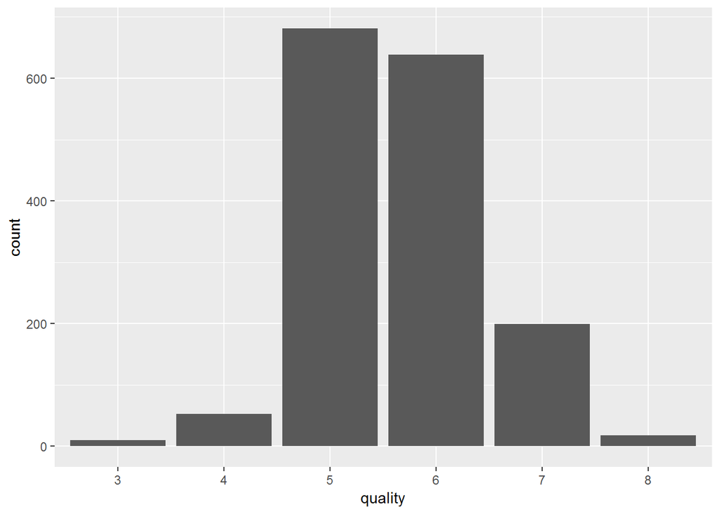

```r
##Plot Quality values to see how many values fro each level of quality
ggplot(aes(x = quality), data = wine_reds) +
  geom_bar()
```

All observations related to qulaity falls between 3 and 8. Also, the majority of our samples have a quality score of either 5 or 6. So, What’s make a wine good(Max = 8) or bad (Min =3)?! which attributes are affecting this score?!

**To make this project applies for good coding practices, i will create a function which i will use in Plot attributes.**

```r
##Function to plot a histogram of a single input variable
plot_univariate <- function(variable, bins = 50) {
  return (ggplot(aes_string(x = variable), data = wine_reds) +
            geom_histogram(bins = bins))
}
```

#### 2.2 Fixed Acidity

**Description:** Most acids involved with wine or fixed or nonvolatile (do not evaporate readily)

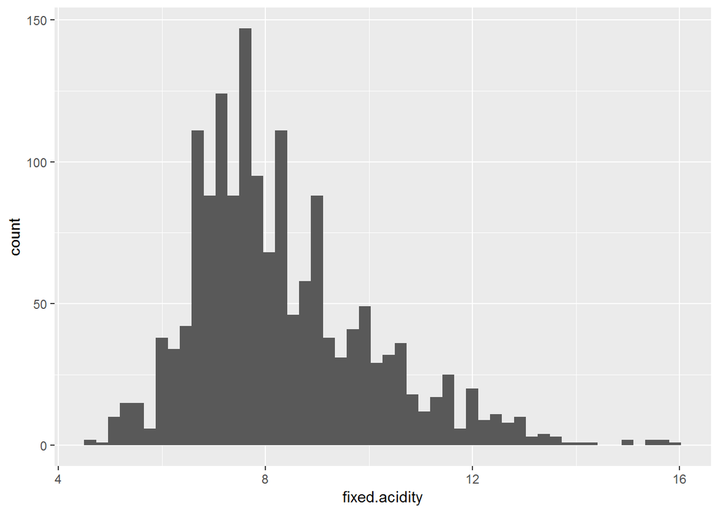

```r
##Plot the Fixed Acidity Values.
plot_univariate('fixed.acidity')
```

All values falls between 4 and 16, with most of values falls between 6 and 9. The distribution is a little bit positively skewed. By using the log scale, it looks more normal distributed.

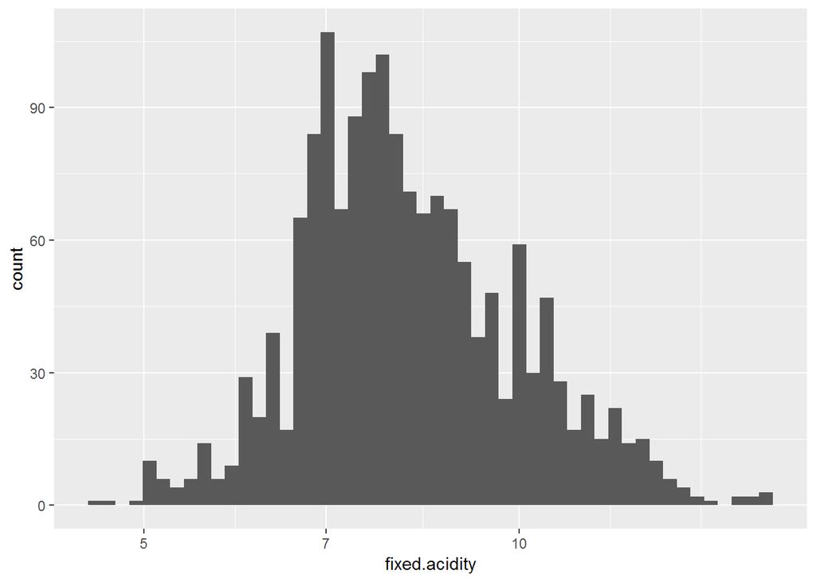

```r
##Plot the Fixed Acidity Values and using the scale_x_log to zoom in the viz.
plot_univariate('fixed.acidity') + scale_x_log10()
```

#### 2.3 Volatile Acidity

**Description:** The amount of acetic acid in wine, which at too high of levels can lead to an unpleasant, vinegar taste.

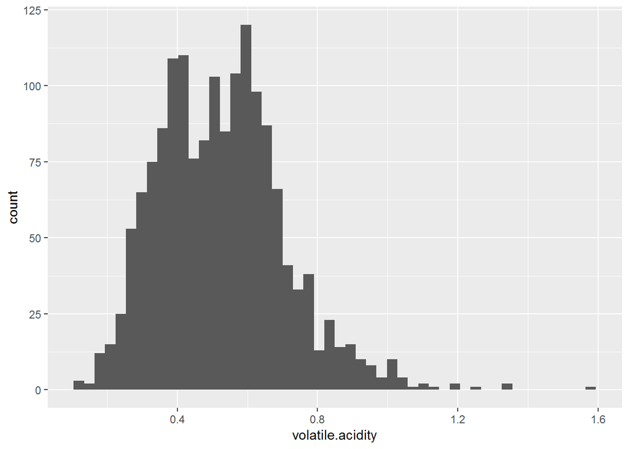

```r
##Plot the Volatile Acidity Values.
plot_univariate('volatile.acidity')
```

Volatile Acidity values falls between 0.1 and 1.6, with majority of values falls between 0.3 and 0.7.The distribution is a little bit positively skewed. I will dig deeper into the values below 1 to understand more about this distribution.

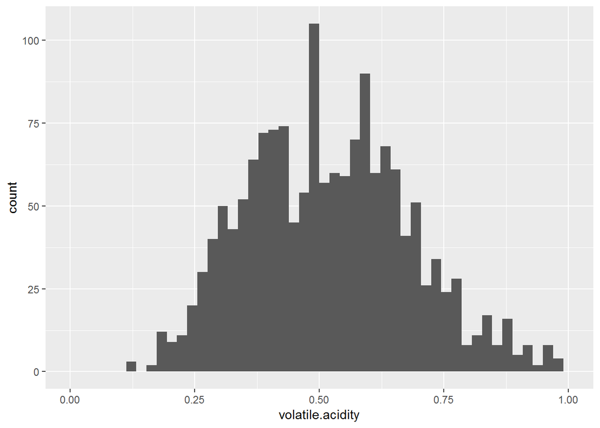

```r
##Plot the Volatile Acidity Values an dusing the scale_x_log to zoom in the viz.
plot_univariate('volatile.acidity') + scale_x_continuous(limits = c(0, 1))
```

#### 2.4 Citric Acid

**Description:** Found in small quantities, citric acid can add ‘freshness’ and flavor to wines.

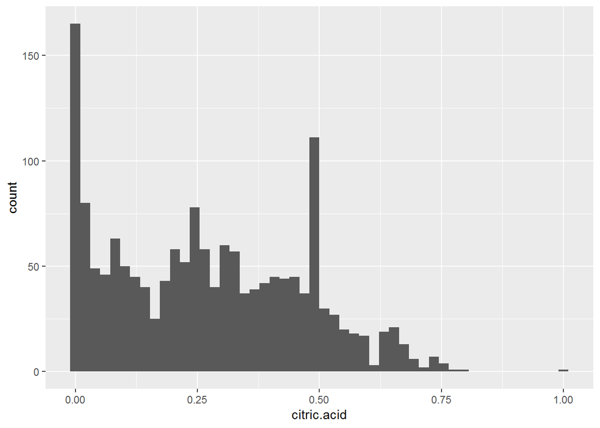

```r
##Plot the Citric Acid Values.
plot_univariate('citric.acid')
```

```r
##To get the number of red wines with citric acid = 0
dim(wine_reds[wine_reds$citric.acid ==0, ])[1]
```

```
## [1] 132
```

All of Citric acid values falls between 0 and 1, with majority of values falls below 0.50 .Also, we have 132 samples with unknown citric acid concentration.

#### 2.5 Residual Sugar

**Description:** The amount of sugar remaining after fermentation stops, it’s rare to find wines with less than 1 gram/liter and wines with greater than 45 grams/liter are considered sweet.

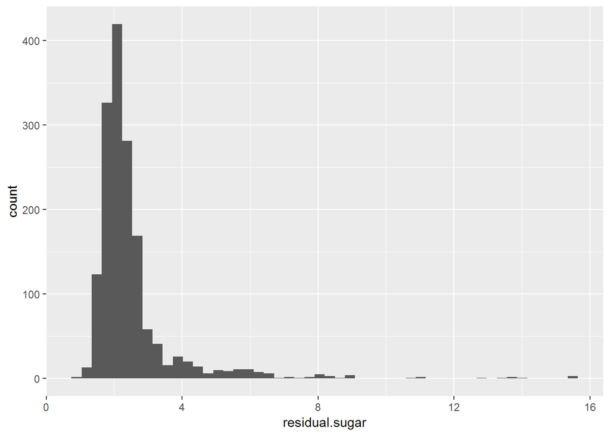

```r
##Plot the Residual Sugar Values.
plot_univariate('residual.sugar')
```

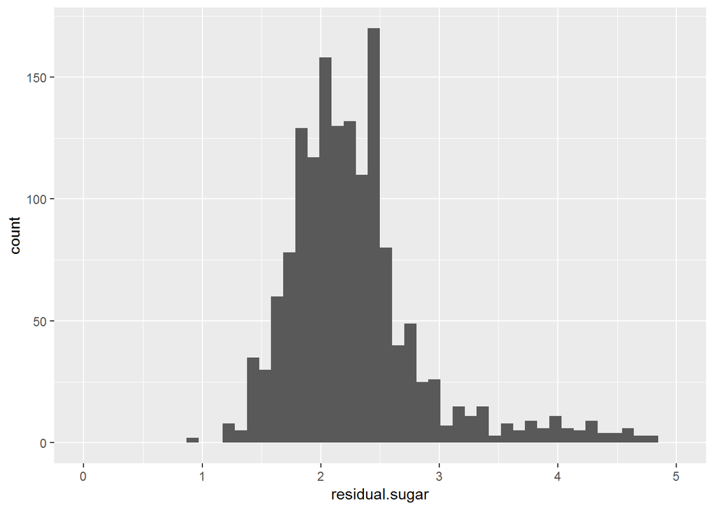

```r
##Plot the Residual Sugar Values and using the scale_x_log function to zoom in the viz.
plot_univariate('residual.sugar') + scale_x_continuous(limits = c(0, 5))
```

Most Residual Sugar values falls between 1.5 and 2.5. There are a few outliers with large values.Also, i zoomed in and look at values below 5, then the distribution looks normal.

#### 2.6 Chlorides

**Description:** The amount of salt in the wine.

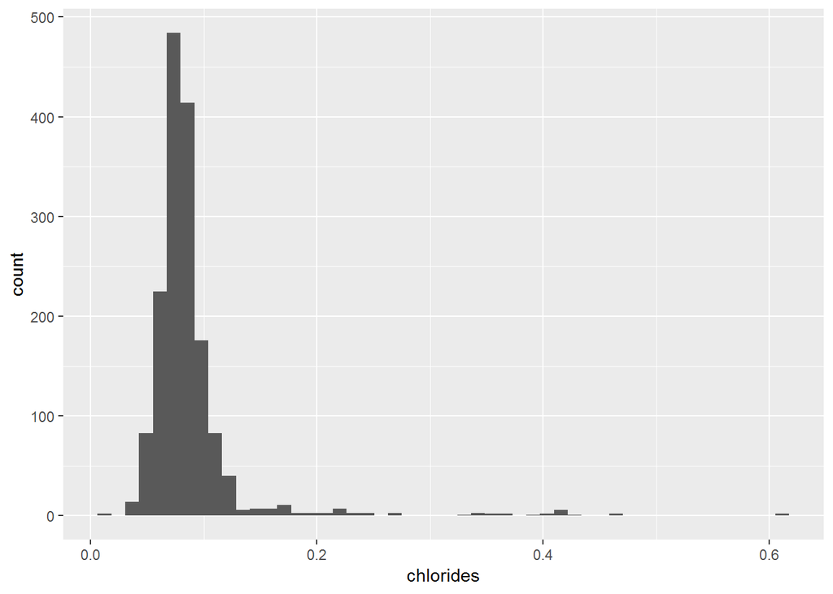

```r
##Plot the Chlorides Values.
plot_univariate('chlorides')
```

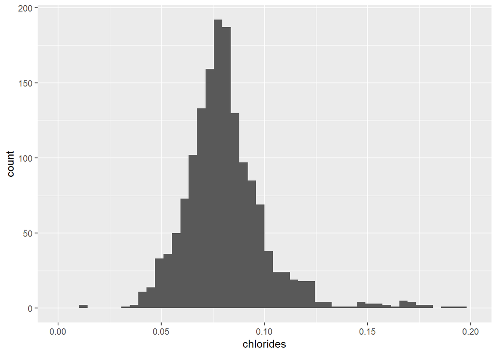

```r
##Plot the Chlorides Values and using the scale_x_log function to zoom in the viz.
plot_univariate('chlorides') + scale_x_continuous(limits = c(0, 0.2))
```

#### 2.7 Free Sulfur Dioxide

**Description:** The free form of SO2 exists in equilibrium between molecular SO2 (as a dissolved gas) and bisulfite ion; it prevents microbial growth and the oxidation of wine.

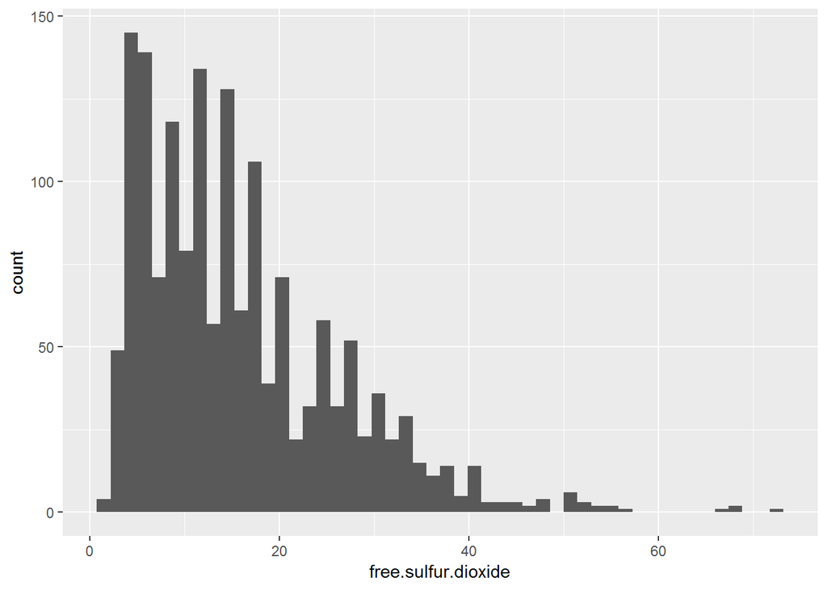

```r
##Plot the Free Sulfur Dioxide Values.
plot_univariate('free.sulfur.dioxide')
```

The distribution of this variable looks highly positively skewed.

#### 2.8 Total sulfur Dioxide

**Description:** The amount of free and bound forms of S02; in low concentrations, SO2 is mostly undetectable in wine, but at free SO2 concentrations over 50 ppm, SO2 becomes evident in the nose and taste of wine.

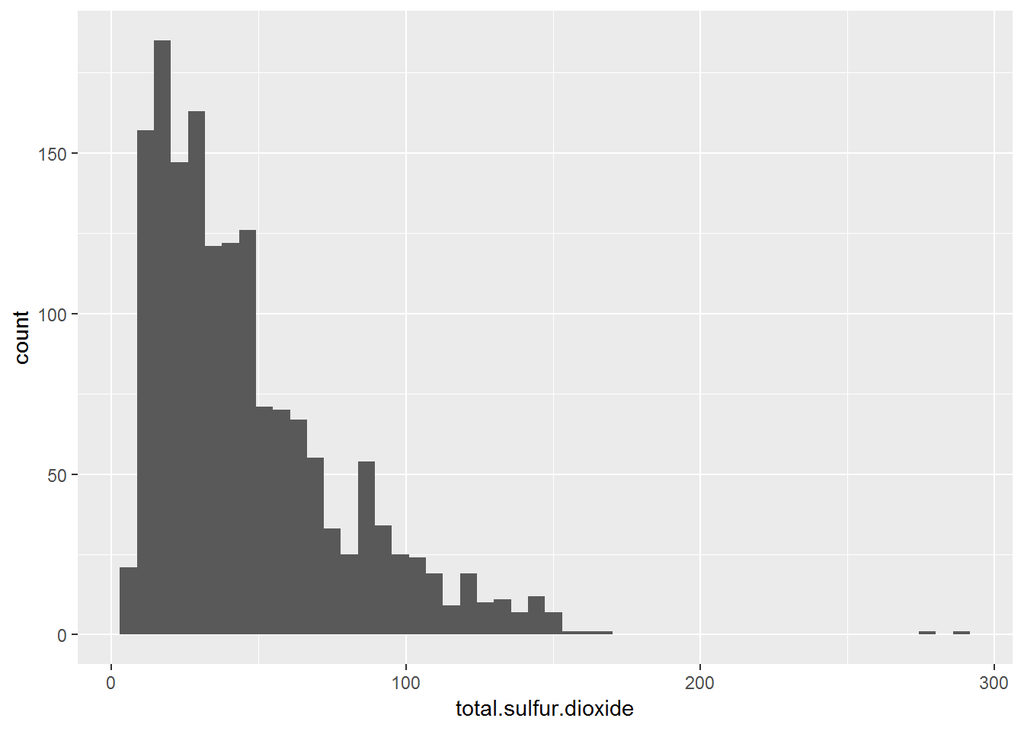

```r
##Plot the total Sulfur Dioxide Values.
plot_univariate('total.sulfur.dioxide')
```

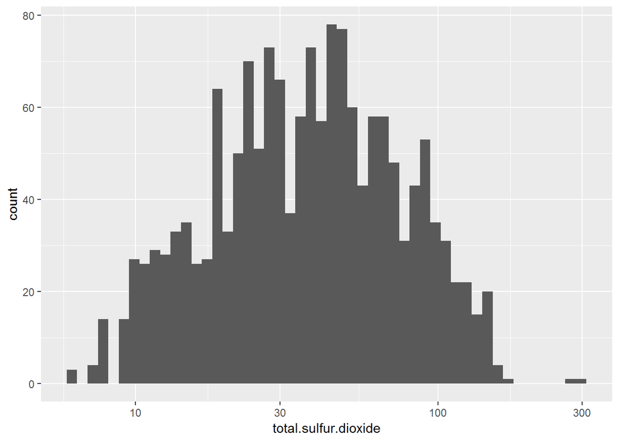

```r
##Plot the Total Sulfur Dioxide Values and using the scale_x_log function to zoom in the viz.
plot_univariate('total.sulfur.dioxide') + scale_x_log10()
```

The distribution of Total sulfur Dioxide looks higly positively skewed. Also, there are a few outliers with very large values, and by using the log scale, it looks more normally distributed.

#### 2.9 Density

**Description:** The density of wine is close to that of water depending on the percent alcohol and sugar content.

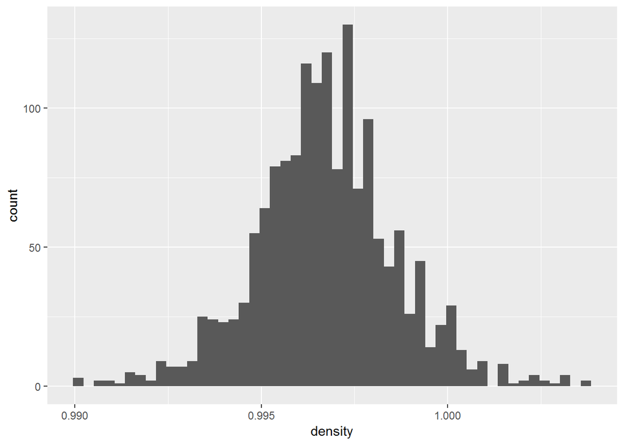

```r
##Plot the Density Values.
plot_univariate('density')
```

Density values falls between 0.990 and 1.004 with majority of values falls between 0.995 and 0.998.

#### 2.10 pH

**Description:** Describes how acidic or basic a wine is on a scale from 0 (very acidic) to 14 (very basic); most wines are between 3-4 on the pH scale.

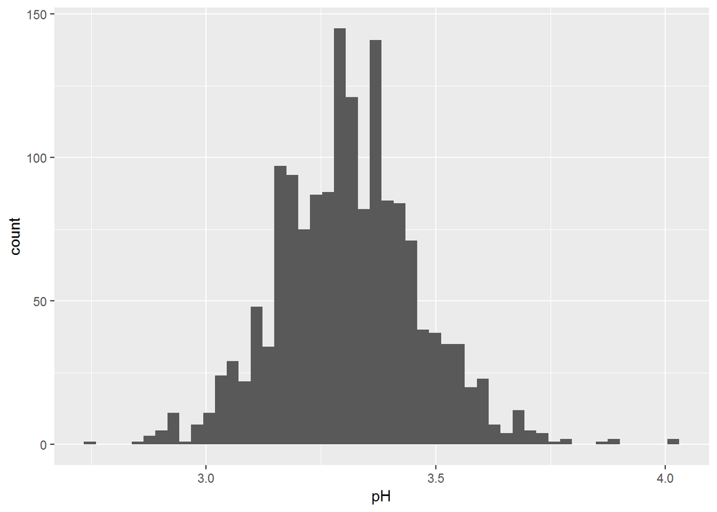

```r
##Plot the pH Values.
plot_univariate('pH')
```

#### 2.11 Sulphates

**Description:** A wine additive which can contribute to sulfur dioxide gas (S02) levels, wich acts as an antimicrobial and antioxidant.

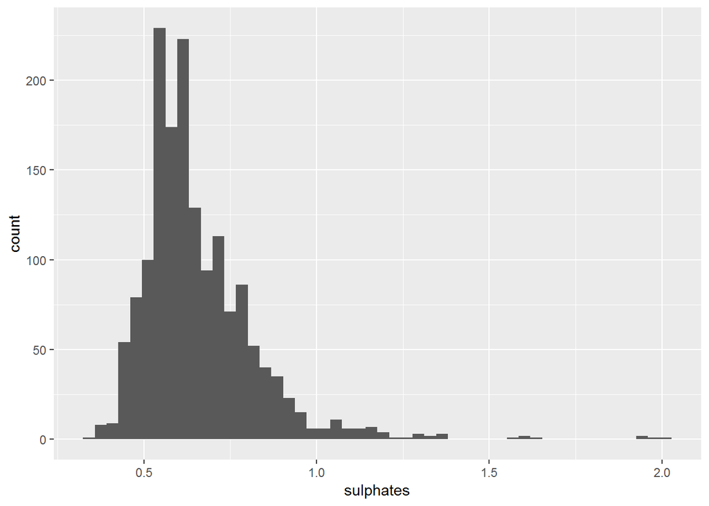

```r
##Plot the sulphates Values.
plot_univariate('sulphates')
```

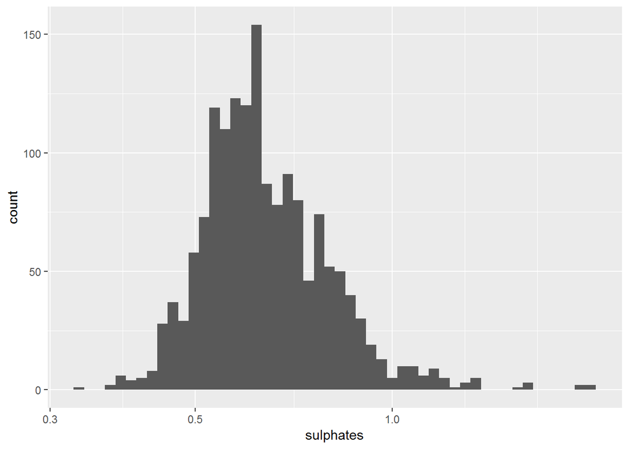

```r
##Plot the Sulphates Values and using the scale_x_log function to zoom in the viz.
plot_univariate('sulphates') + scale_x_log10()
```

The distribution of sulphates looks higly positively skewed. Also, there are a few outliers with very large values, and by using the log scale, it looks more normally distributed.

#### 2.12 Alcohol

**Description:** The percent alcohol content of the wine.

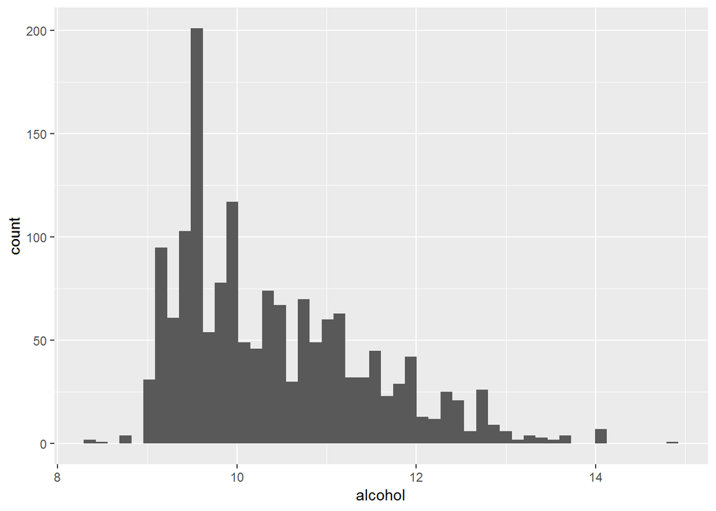

```r
##Plot the alcohol Values.
plot_univariate('alcohol')
```

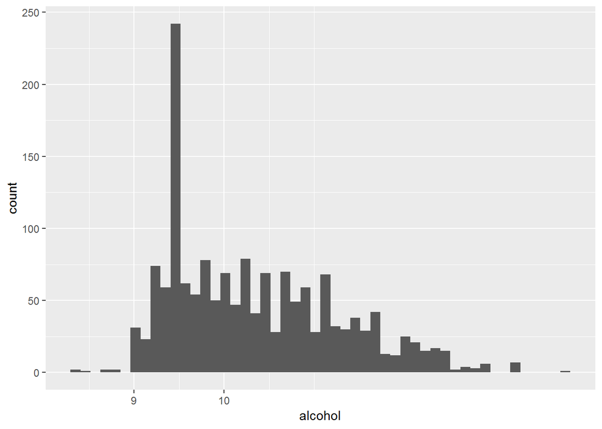

```r
##Plot the Alcohol Values and using the scale_x_log function to zoom in the viz.
plot_univariate('alcohol') + scale_x_log10()
```

The Alcohol values falls between 8.5 and 15. The distribution of alcohol value is positively skewed. By using the log scale, it looks more normally distributed.

## 3- Univariate Analysis

**What is the structure of your dataset?**

There are 12 attributes with total 1599 different red wines in the dataset. 11 of them are input attributes based on physicochemical tests. The other attribute (Quality) is the output attribute based on sensory data.

**What is/are the main feature(s) of interest in your dataset?**

The main feature of interest is the output attribute **quality**. I am trying to figure out which of the 11 input attributes are contributing to a high quality score.

**What other features in the dataset do you think will help support your investigation into your feature(s) of interest?**

The input attributes are equally likely to contribute to the quality score at this point. I will dig deeper into how each attribute is distributed with a given quality value in the next section where i will discuss bivariate exploration process.

**Did you create any new variables from existing variables in the dataset?**

I didn’t need to create new variables. All i need to create was a function body to use it while Plot univariate attributes in avoidance of repetitive code.

**Of the features you investigated, were there any unusual distributions? Did you perform any operations on the data to tidy, adjust, or change the form of the data? If so, why did you do this?**

All values of quality falls between 0 to 10, but our data set only has quality values from 3 to 8, which means there are no extremely bad red wines or extrememly good wines in our data set. The majority of red wines in the data set has a quality value either 5 or 6, with a little bit number of wines with quality values 3, 4, 7 or 8.

## 4- Bivariate Exploration

In this section, I will dig deeper into how each input attribute is related to the output Quality variable.

```r
##Function to plot boxplot of  input variable. Also, i use group by Quality variable
plot_bivariate <- function(variable) {
  return (ggplot(aes_string(x = 'quality', y = variable), data = wine_reds) +
            geom_boxplot())
}
```

#### 4.1 Quality vs Fixed Acidity

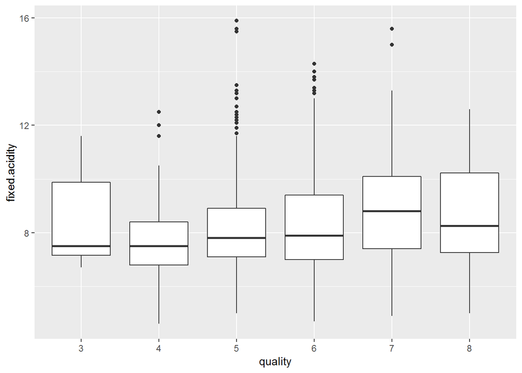

```r
##Plot Qulaity Values vs Fixed Acidity values.
plot_bivariate('fixed.acidity')
```

There is not a clear relation between quality and fixed acidity.

#### 4.2 Quality vs Volatile Acidity

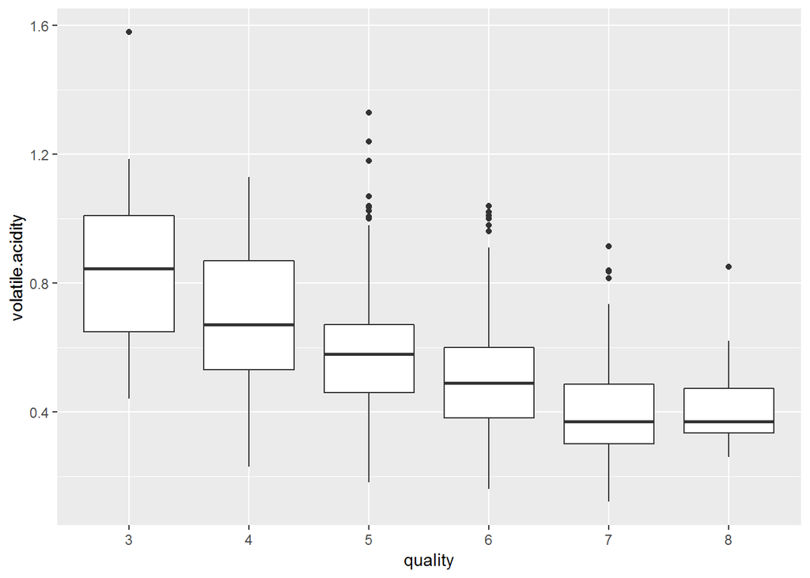

```r
##Plot Qulaity Values vs Volatile Acidity values.
plot_bivariate('volatile.acidity')
```

The higher the volatile acidity within the wine, the lower qulaity of wine produced.

#### 4.3 Quality vs Citric Acid

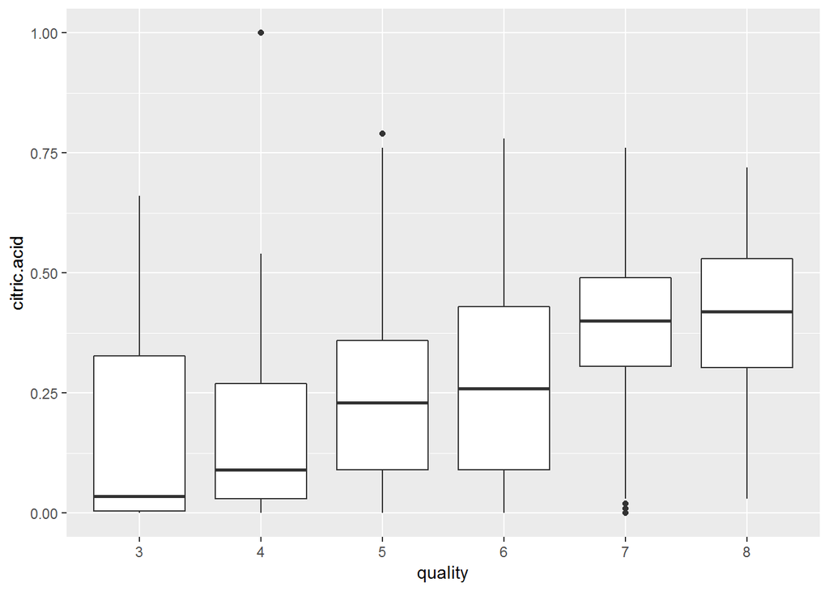

```r
##Plot Qulaity Values vs Citric Acid values.
plot_bivariate('citric.acid')
```

The higher the citric acidity within the wine, the higher qulaity of wine produced.

#### 4.4 Quality vs Residual Sugar

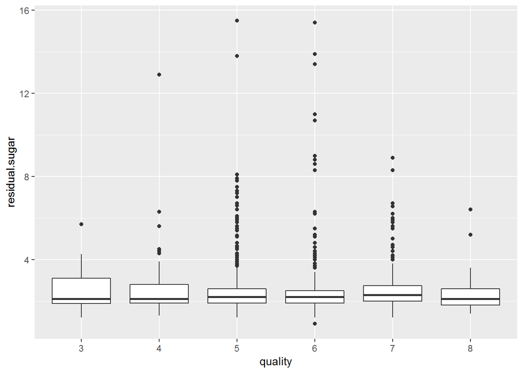

```r
##Plot Qulaity Values vs Residual Sugar values.
plot_bivariate('residual.sugar')
```

There is not a clear relation between quality and residual sugar.

#### 4.5 Quality vs Chlorides

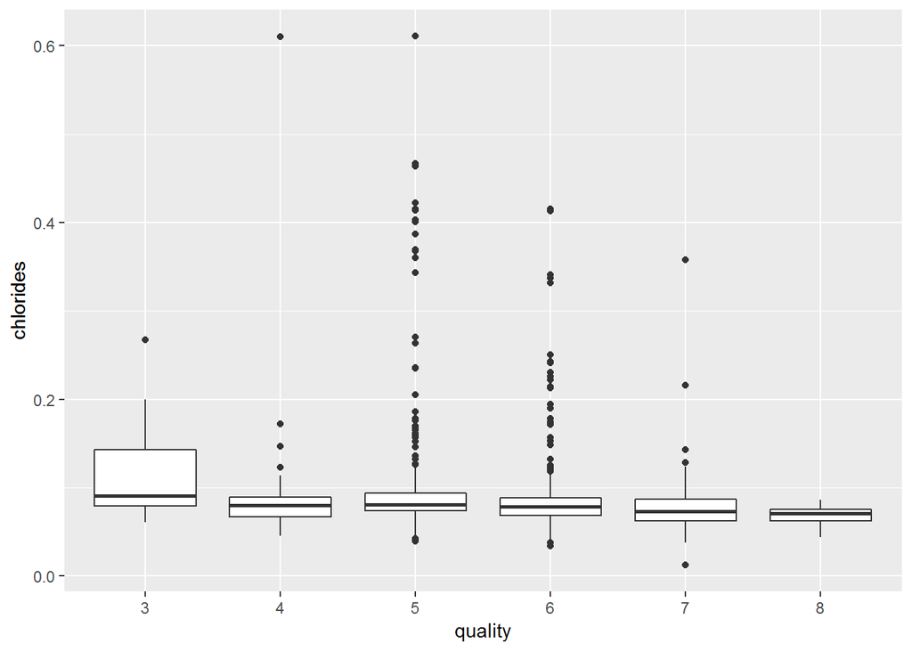

```r
##Plot Qulaity Values vs Chlorides values.
plot_bivariate('chlorides')
```

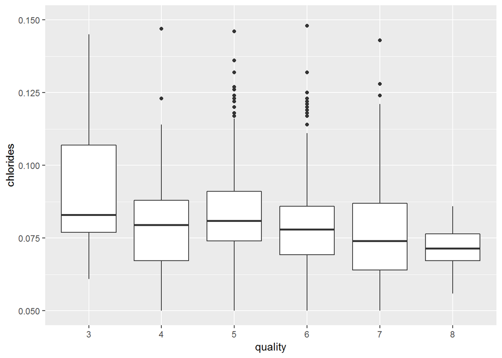

```r
##Plot Qulaity Values vs Fixed Acidity values and using the scale_y_continuous function to zoom in the viz.
plot_bivariate('chlorides') + scale_y_continuous(limits = c(0.05, 0.15))
```

After looking closer for values which falls between these values 0.05, 0.15, i found that the more chlorides the wine have, the lower the qulaity is.

#### 4.6 Quality vs Free Sulfur Dioxide

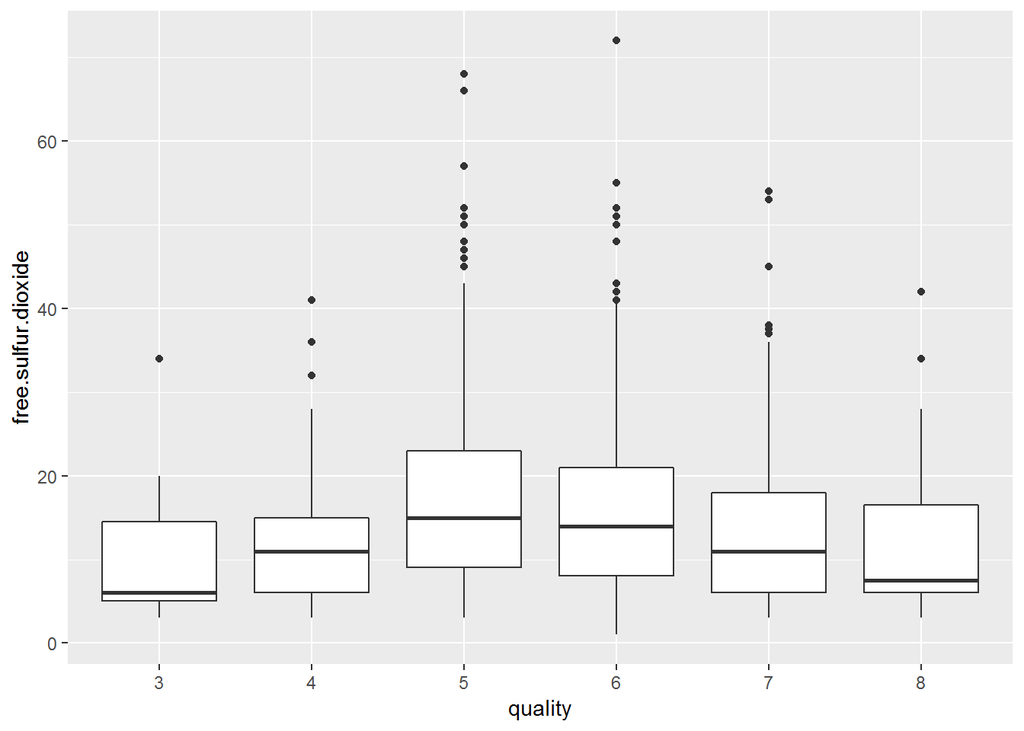

```r
##Plot Qulaity Values vs Free Sulfur Dioxide values.
plot_bivariate('free.sulfur.dioxide')
```

There is not a clear relation between quality and free sulfur dioxide.

#### 4.7 Quality vs Total Sulfur Dioxide

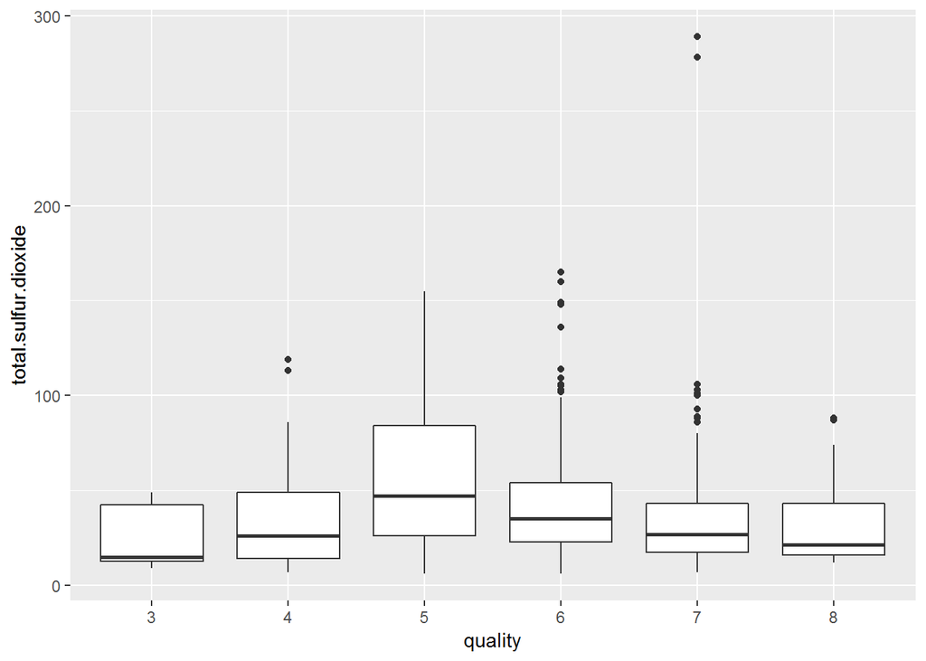

```r
##Plot Qulaity Values vs Total Sulfur Dioxide values.
plot_bivariate('total.sulfur.dioxide')
```

There is not a clear relation between quality and total sulfur dioxide.

#### 4.8 Quality vs Density

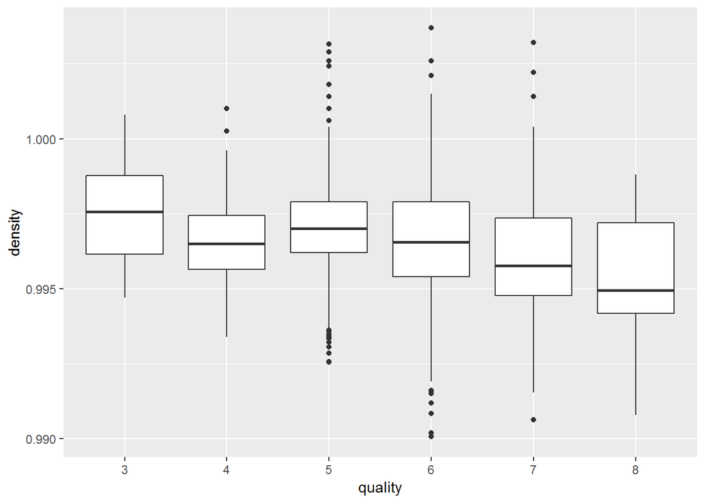

```r
##Plot Qulaity Values vs Density values.
plot_bivariate('density')
```

The lower the density within the wine, the higher qulaity of wine produced.

#### 4.9 Quality vs pH

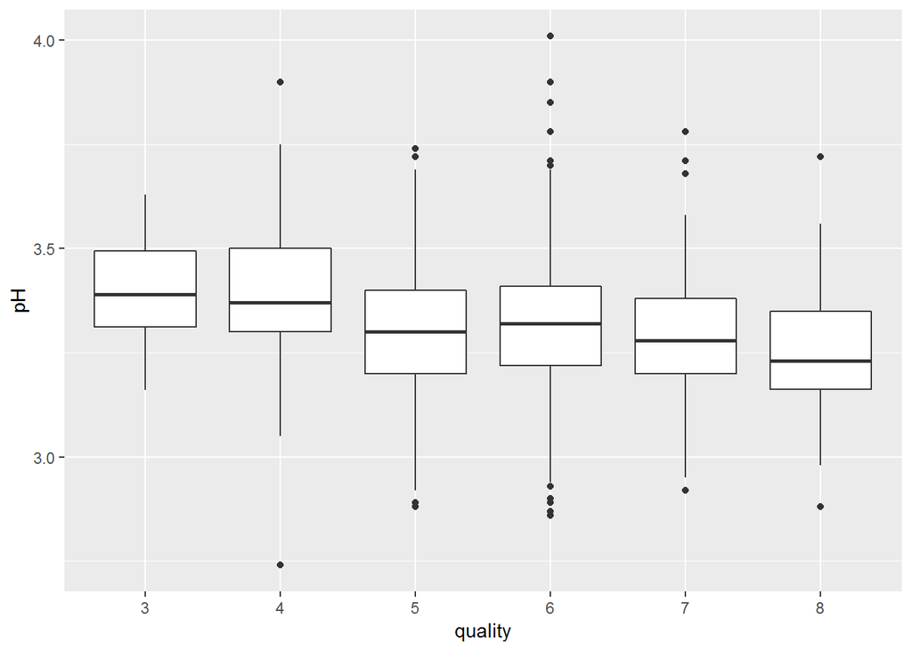

```r
##Plot Qulaity Values vs pH values.
plot_bivariate('pH')
```

The lower the pH is, the higher the quality is.

#### 4.10 Quality vs sulphates

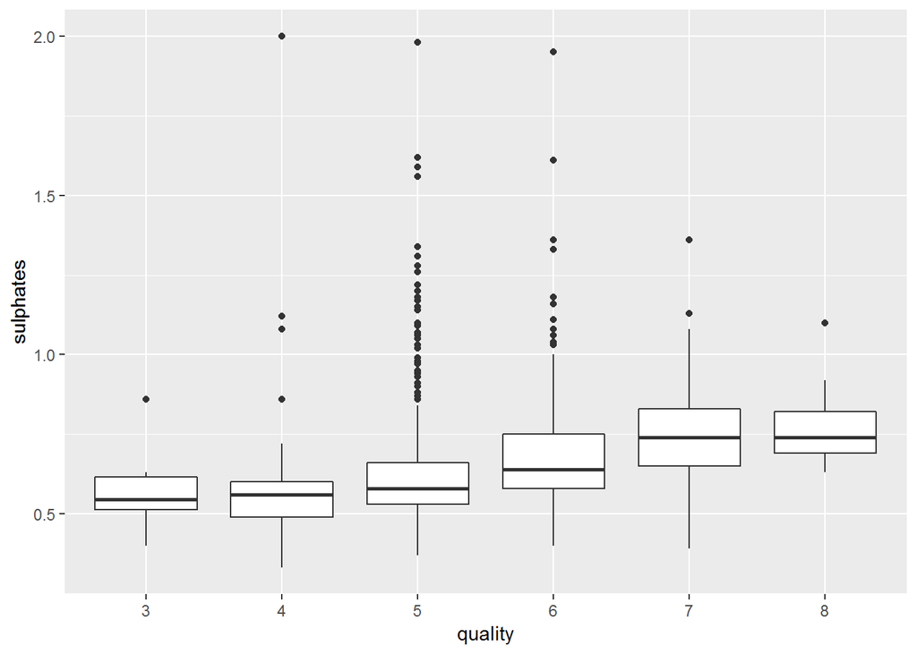

```r
##Plot Qulaity Values vs Sulphates values.
plot_bivariate('sulphates')
```

The higher the quality is, the higher the sulphates within the wine.

#### 4.11 Qulaity vs Alcohol

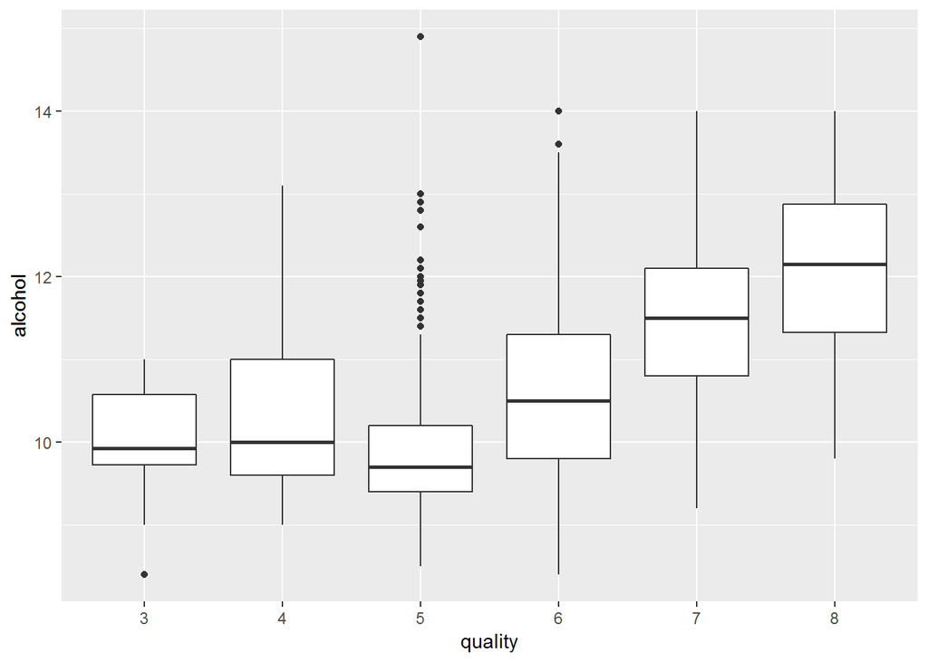

```r
##Plot Qulaity Values vs Alcohol values.
plot_bivariate('alcohol')
```

The higher the quality is, the higher the alcohol within the wine.

**After i had a look on how each input attribute is related to the output variable Quality, In this section, i will find the correlation between all possible pairs of this dataset. Then, i will examine (if exist) any interesting pairs.**